# Binomial Distribution

# Introduction

This entire paragraph was taken over from the Introduction to Statistical Thought (written by Michael Lavine; published on June 24, 2010).

Statisticians often have to consider observations of the following type:

- A repeatable event results in either a success or a failure.
- Many repetitions are observed
- Successes and failures are counted
- The number of successes helps us learn about the probability of success.

Because binomial experiments are so prevalent there is specialized language to describe them. Each repetition is called a trial; the number of trials is usually denoted N; the unknown probability of success is usually denoted either *p* or *θ*; the number of successes is usually denoted *X*. We write *X ∼ Bin(N, p)* . The symbol “∼” is read is distributed as; we would say “X is distributed as Binomial N p” or “X has the Binomial N, p distribution”.

Some important assumptions about binomial experiments are that *N* is fixed in advance, *θ* is the same for every trial, and the outcome of any trial does not influence the outcome of any other trial.

# Generating binomial data

Let’s create a function *summarize.binomial.observations*, which takes the following parameters:

- trials - a number of trials (*N*)
- theta - a probability of success (*θ*)
- observations - a number of observations to be made

```r
library(tidyverse)
summarize.binomial.observations <- function(trials, theta, observations) {
  sample.space <- c(1,0)
  results <- 1:observations %>%
  map_int(function(x)
    as.integer(
      sum(
        sample(sample.space, size = trials, replace = TRUE, prob = c(theta, 1 - theta))
      )
    )
  )
  return(results)
}
```

Now we can use the function to generate 3000 observations of X ∼ Bin(80, 0.6):

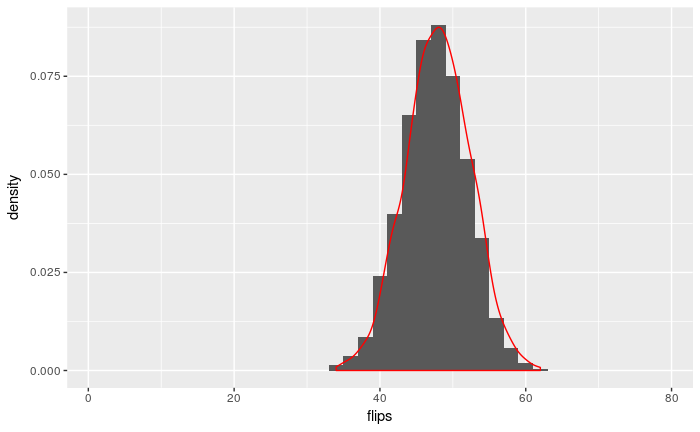

```r
summary <- summarize.binomial.observations(80, 0.6, 3000)
resulting.df <- data.frame(flips <- summary) # ggplot only works with data frames
names(resulting.df) <- c("flips")
#binPDF <- data.frame(x<-1:80, y<-dbinom(1:80, size=80, prob = 0.6))
#names(binPDF) <- c("flips", "prob")
ggplot(resulting.df) +
  geom_histogram(breaks=seq(1, 80, 2), aes(x=flips, y=..density..), position="identity") +
  geom_density(aes(x=flips, y = ..density..), colour="red") # + geom_line(data=binPDF, aes(flips, prob), colour="blue")
```

It turns out that R already contains a function which produces the same data as *summarize.binomial.observations*. The function is called *rbinom* and it repeatedly performs a random draw from a binomial distribution.

```r
drawsV1 <- summarize.binomial.observations(80, 0.6, 3000)
drawsV2 <- rbinom(3000, 80, 0.6)
mean(drawsV1)
```

```
[1] 48.05033
```

```r
mean(drawsV2)
```

```
[1] 47.859
```

```r
length(drawsV1)
```

```
[1] 3000
```

```r
length(drawsV2)
```

```
[1] 3000
```

# Mean, Variance and Standard Deviation

The mean (expected value), variance and standard deviation can be calculated as follows:

```r
dist <- rbinom(3000, 80, 0.6)
mean(dist)
```

```
[1] 48.03033
```

```r
var(dist) # variance
```

```
[1] 19.34586
```

```r
sqrt(var(dist)) # standard deviation
```

```
[1] 4.398393
```

Roughly 2/3 of the sample falls within about 1 standard deviation of the mean:

```r
sd <- sqrt(var(dist))
mean((dist >= (mean(dist) - sd)) & (dist <= (mean(dist) + sd)))
```

```
[1] 0.6926667
```

Roughly 95% of the sample falls within about 2 standard deviations of the mean:

```r
mean((dist >= (mean(dist) - 2*sd)) & (dist <= (mean(dist) + 2*sd)))
```

```
[1] 0.9463333
```

# Probability Density

The probability of observing exactly 5 heads out of 10 flips can be estimated as

```r
mean(rbinom(1000, 10, .5) == 5)
```

```
[1] 0.27
```

There is a special function in R which calculates the probability density - it is called *dbinom*:

```r
dbinom(5, 10, .5)
```

```
[1] 0.2460938
```

# Cumulative Density

The probability of observing exactly at most 4 heads out of 10 flips can be estimated as

```r
mean(rbinom(1000, 10, .5) <= 4)
```

```
[1] 0.371
```

There is a special function in R which calculates the cumulative density - it is called *pbinom*:

```r
pbinom(4, 10, .5)
```

```
[1] 0.3769531
```

# Quantiles

Quantile works as an inverse of the cumulative density function, as illustrated below:

```r
qbinom(pbinom(4, 10, .5), 10, .5)
```

```
[1] 4
```

Visit [Basic Probability Distributions in R](https://rpubs.com/ggraham412/100906) for more information.

# Quantile-Quantile Plots

As described in the [Q-Q Plot Tutorial](https://intellinexus.wordpress.com/2010/11/29/creating-a-q-q-plot/), The quantile-quantile (q-q) plot is a graphical technique for determining if two data sets come from populations with a common distribution.

The following code compares observations stored in *x.sample* with those in *y.sample*:

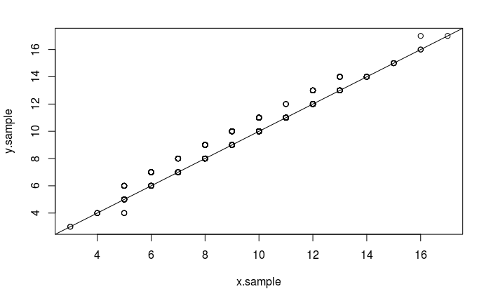

```r
x.sample <- rbinom(1000, 19, .5)
y.sample <- rbinom(1000, 19, .5)
qqplot(x.sample, y.sample)
abline(0,1)
```

The same test using *ggplot2*:

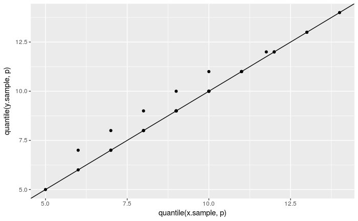

```r
nq <- 31
p <- (1 : nq) / nq - 0.5 / nq
ggplot() + geom_point(aes(x = quantile(x.sample, p), y = quantile(y.sample, p))) +
  geom_abline(intercept = 0, slope = 1)
```

Do the following to compare the *x.sample* with a binomial distribution Bin(19, 0.5):

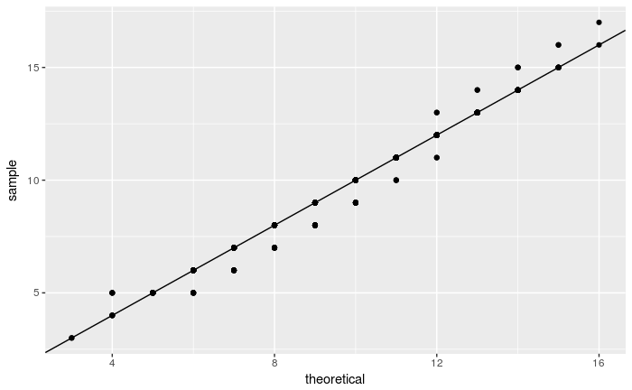

```r
xdf <-data.frame(x = x.sample)
ggplot(xdf, aes(sample = x)) +
  stat_qq(distribution = stats::qbinom, dparams = list(size = 19, prob=0.5)) +
  geom_abline(intercept = 0, slope = 1)
```

# Further Reading

- [A quantile-quantile plot](http://ggplot2.tidyverse.org/reference/geom_qq.html)
- [QQ Plots and PP Plots](http://homepage.divms.uiowa.edu/~luke/classes/STAT4580/qqpp.html)
- [Q-Q Plot Tutorial](https://intellinexus.wordpress.com/2010/11/29/creating-a-q-q-plot/)